# Lab 7 homework

Nicholas Nagle

April 13, 2015

For your homework, you should analyze the *Titanic* dataset, identify the determinants of survival for passengers on the Titanic, and prepare a brief report of your findings. In addition you should identify whether the imputations of age impact the result. (Some of the age data were missing, and were *imputed*, or estimated. See the Notes below the Variable Descriptions.)

VARIABLE DESCRIPTIONS:

- survival: Survival (0 = No; 1 = Yes)
- pclass: Passenger Class (1 = 1st; 2 = 2nd; 3 = 3rd)
- name: Name
- sex: Sex
- age: Age
- sibsp: Number of Siblings/Spouses Aboard
- parch: Number of Parents/Children Aboard
- ticket: Ticket Number
- fare: Passenger Fare
- cabin: Cabin
- embarked: Port of Embarkation (C = Cherbourg; Q = Queenstown; S = Southampton)

SPECIAL NOTES:

Pclass is a proxy for socio-economic status (SES)

1st ~ Upper; 2nd ~ Middle; 3rd ~ Lower

Age is in Years; Fractional if Age less than One (1)

If the Age is Estimated, it is in the form xx.5

With respect to the family relation variables (i.e. sibsp and parch) some relations were ignored. The following are the definitions used for sibsp and parch.

- Sibling: Brother, Sister, Stepbrother, or Stepsister of Passenger Aboard Titanic
- Spouse: Husband or Wife of Passenger Aboard Titanic (Mistresses and Fiances Ignored)
- Parent: Mother or Father of Passenger Aboard Titanic
- Child: Son, Daughter, Stepson, or Stepdaughter of Passenger Aboard Titanic

Other family relatives excluded from this study include cousins, nephews/nieces, aunts/uncles, and in-laws. Some children travelled only with a nanny, therefore parch=0 for them. As well, some travelled with very close friends or neighbors in a village, however, the definitions do not support such relations.

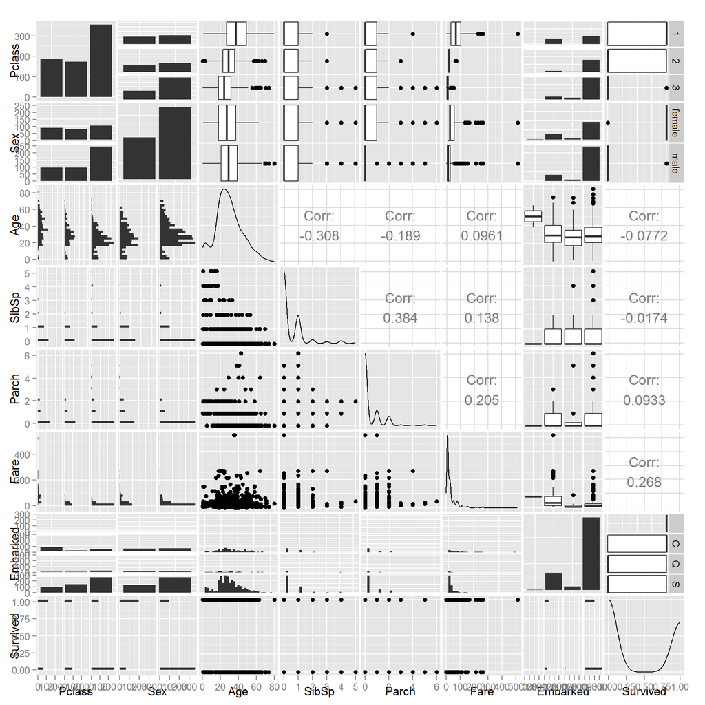

```r
# Loading libraries
library('ggplot2')
library('dplyr')
library('GGally')
library('car')

# Loading the data
setwd('F:/Documents/Geography_415/dpaulse1/homework7')
titanic <- read.csv('titanic.csv')

# Factoring the categorical variables
titanic$Pclass <- as.factor(titanic$Pclass)
titanic$Sex <- as.factor(titanic$Sex)
titanic$Embarked <- as.factor(titanic$Embarked)

# Looking at the relationships in the data using correlation matrix
titanic %>% filter(!is.na(Age)) %>% select(Pclass, Sex, Age, SibSp, Parch,
  Fare, Embarked, Survived) %>% ggpairs()
```

- From the correlation matrix, we see that there definitely appears to be a relationship between Pclass and Survived. There also appears to be a strong correlation between Sex and Survived. Fare and Survived also seems highly related (although, I will likely remove this variable as it will likely be very similar to the Pclass variable).

```r
# Model with all variables from ggpairs analysis
reg0 <- glm(Survived ~ . - PassengerId - Name - Ticket - Cabin, data=titanic,
  family=binomial(link='logit'))
summary(reg0)
```

```
##
## Call:
## glm(formula = Survived ~ . - PassengerId - Name - Ticket - Cabin,
##     family = binomial(link = "logit"), data = titanic)
##
## Deviance Residuals:
##     Min       1Q   Median       3Q      Max
## -2.7220  -0.6455  -0.3770   0.6293   2.4461
##
## Coefficients:
##               Estimate Std. Error z value Pr(>|z|)
## (Intercept)  16.691979 607.920015   0.027 0.978095
## Pclass2      -1.189637   0.329197  -3.614 0.000302 ***
## Pclass3      -2.395220   0.343356  -6.976 3.04e-12 ***
## Sexmale      -2.637859   0.223006 -11.829  < 2e-16 ***
## Age          -0.043308   0.008322  -5.204 1.95e-07 ***
## SibSp        -0.362925   0.129290  -2.807 0.005000 **
## Parch        -0.060365   0.123944  -0.487 0.626233
## Fare          0.001451   0.002595   0.559 0.576143
## EmbarkedC   -12.259048 607.919885  -0.020 0.983911
## EmbarkedQ   -13.082427 607.920088  -0.022 0.982831
## EmbarkedS   -12.661895 607.919868  -0.021 0.983383
## ---
## Signif. codes:  0 '***' 0.001 '**' 0.01 '*' 0.05 '.' 0.1 ' ' 1
##
## (Dispersion parameter for binomial family taken to be 1)
##
##     Null deviance: 964.52  on 713  degrees of freedom
## Residual deviance: 632.34  on 703  degrees of freedom
##   (177 observations deleted due to missingness)
## AIC: 654.34
##
## Number of Fisher Scoring iterations: 13
```

- First, I ran the model with all predictor variables other than those that made very litte sense or were uncommonly reported. I did not see any reason PassengerId or Name would influence whether a person survived, so I did not inlcude those. The Ticket number could be helpful, but it would likely provide most of the same information as the Pclass variable (the first number commonly commonly refers to the class of the passenger). I did not use Cabin because there were few observations with the cabin listed.
- Next, because I think Fare is so closely related to Pclass and it is statistically insignificant according to the regression summary, I am going to remove Fare.

```r
reg1 <- update(reg0, . ~ . - Fare)
summary(reg1)
```

```
##
## Call:
## glm(formula = Survived ~ Pclass + Sex + Age + SibSp + Parch +
##     Embarked, family = binomial(link = "logit"), data = titanic)
##
## Deviance Residuals:
##     Min       1Q   Median       3Q      Max
## -2.6970  -0.6427  -0.3784   0.6270   2.4538
##
## Coefficients:
##               Estimate Std. Error z value Pr(>|z|)
## (Intercept)  16.830381 607.655774   0.028  0.97790
## Pclass2      -1.268362   0.298428  -4.250 2.14e-05 ***
## Pclass3      -2.493756   0.296219  -8.419  < 2e-16 ***
## Sexmale      -2.641145   0.222801 -11.854  < 2e-16 ***
## Age          -0.043725   0.008294  -5.272 1.35e-07 ***
## SibSp        -0.355755   0.128529  -2.768  0.00564 **
## Parch        -0.044628   0.120705  -0.370  0.71159
## EmbarkedC   -12.260112 607.655693  -0.020  0.98390
## EmbarkedQ   -13.104581 607.655894  -0.022  0.98279
## EmbarkedS   -12.687791 607.655674  -0.021  0.98334
## ---
## Signif. codes:  0 '***' 0.001 '**' 0.01 '*' 0.05 '.' 0.1 ' ' 1
##
## (Dispersion parameter for binomial family taken to be 1)
##
##     Null deviance: 964.52  on 713  degrees of freedom
## Residual deviance: 632.67  on 704  degrees of freedom
##   (177 observations deleted due to missingness)
## AIC: 652.67
##
## Number of Fisher Scoring iterations: 13
```

```r
anova(reg0, reg1, test="Chisq")
```

```
## Analysis of Deviance Table
##
## Model 1: Survived ~ (PassengerId + Pclass + Name + Sex + Age + SibSp +
##     Parch + Ticket + Fare + Cabin + Embarked) - PassengerId -
##     Name - Ticket - Cabin
## Model 2: Survived ~ Pclass + Sex + Age + SibSp + Parch + Embarked
##   Resid. Df Resid. Dev Df Deviance Pr(>Chi)
## 1       703     632.34
## 2       704     632.67 -1 -0.32914   0.5662
```

```r
coef(reg0)
```

```
##   (Intercept)       Pclass2       Pclass3       Sexmale           Age
##  16.691978617  -1.189637192  -2.395219882  -2.637859199  -0.043308466
##         SibSp         Parch          Fare     EmbarkedC     EmbarkedQ
##  -0.362925199  -0.060365143   0.001450584 -12.259047516 -13.082426967
##     EmbarkedS
## -12.661895127
```

```r
coef(reg1)
```

```
##  (Intercept)      Pclass2      Pclass3      Sexmale          Age
##  16.83038124  -1.26836242  -2.49375637  -2.64114459  -0.04372504
##        SibSp        Parch    EmbarkedC    EmbarkedQ    EmbarkedS
##  -0.35575495  -0.04462755 -12.26011199 -13.10458071 -12.68779111
```

- There are three reasons to support getting rid of the Fare variable. One, the AIC in the new regression model is slightly lower. Second, the ANOVA results show that there is little difference between the models. Finally, the coefficients of the remaining variables do not change much when it is removed from the model.
- Looking at the remaining variables, I wonder whether Embarked deserves to be in the model. I do not think that the port at which a passenger embarked would have much, if any, influence upon whether or not they survived. Therefore, the next model I created removed the Embarked variable.

```r
reg2 <- update(reg1, . ~ . - Embarked)
summary(reg2)
```

```
##
## Call:
## glm(formula = Survived ~ Pclass + Sex + Age + SibSp + Parch,
##     family = binomial(link = "logit"), data = titanic)
##
## Deviance Residuals:
##     Min       1Q   Median       3Q      Max
## -2.7723  -0.6353  -0.3869   0.6327   2.4513
##
## Coefficients:
##              Estimate Std. Error z value Pr(>|z|)
## (Intercept)  4.356474   0.455990   9.554  < 2e-16 ***
## Pclass2     -1.415376   0.284712  -4.971 6.65e-07 ***
## Pclass3     -2.650169   0.285724  -9.275  < 2e-16 ***
## Sexmale     -2.642267   0.219749 -12.024  < 2e-16 ***
## Age         -0.044836   0.008229  -5.448 5.09e-08 ***
## SibSp       -0.368280   0.126827  -2.904  0.00369 **
## Parch       -0.038607   0.119601  -0.323  0.74685
## ---
## Signif. codes:  0 '***' 0.001 '**' 0.01 '*' 0.05 '.' 0.1 ' ' 1
##
## (Dispersion parameter for binomial family taken to be 1)
##
##     Null deviance: 964.52  on 713  degrees of freedom
## Residual deviance: 636.46  on 707  degrees of freedom
##   (177 observations deleted due to missingness)
## AIC: 650.46
##
## Number of Fisher Scoring iterations: 5
```

```r
anova(reg1, reg2, test="Chisq")
```

```
## Analysis of Deviance Table
##
## Model 1: Survived ~ Pclass + Sex + Age + SibSp + Parch + Embarked
## Model 2: Survived ~ Pclass + Sex + Age + SibSp + Parch
##   Resid. Df Resid. Dev Df Deviance Pr(>Chi)
## 1       704     632.67
## 2       707     636.46 -3  -3.7887   0.2852
```

```r
coef(reg1)
```

```
##  (Intercept)      Pclass2      Pclass3      Sexmale          Age
##  16.83038124  -1.26836242  -2.49375637  -2.64114459  -0.04372504
##        SibSp        Parch    EmbarkedC    EmbarkedQ    EmbarkedS
##  -0.35575495  -0.04462755 -12.26011199 -13.10458071 -12.68779111
```

```r
coef(reg2)
```

```
## (Intercept)     Pclass2     Pclass3     Sexmale         Age       SibSp
##  4.35647443 -1.41537613 -2.65016872 -2.64226651 -0.04483609 -0.36828015
##       Parch
## -0.03860705
```

- Just like the previous model which removed Fare, all three tests show statistical evidence that Embarked is not an important variable in determining whether or not a passenger survived.
- Looking at the summary of the regression model, the last variable that is shown to be statistically inisignificant is Parch, the number of parents/children aboard. Personally, I would think that this would be more significant than it is, although maybe it is because of how closely related it is to SibSp. Still, I will next try a model without Parch to see if there is statistical evidence to drop it or not.

```r
reg3 <- update(reg2, . ~ . - Parch)
summary(reg3)
```

```
##
## Call:
## glm(formula = Survived ~ Pclass + Sex + Age + SibSp, family = binomial(link = "logit"),
##     data = titanic)
##
## Deviance Residuals:
##     Min       1Q   Median       3Q      Max
## -2.7876  -0.6417  -0.3864   0.6261   2.4539
##
## Coefficients:
##              Estimate Std. Error z value Pr(>|z|)
## (Intercept)  4.334201   0.450700   9.617  < 2e-16 ***
## Pclass2     -1.414360   0.284727  -4.967 6.78e-07 ***
## Pclass3     -2.652618   0.285832  -9.280  < 2e-16 ***
## Sexmale     -2.627679   0.214771 -12.235  < 2e-16 ***
## Age         -0.044760   0.008225  -5.442 5.27e-08 ***
## SibSp       -0.380190   0.121516  -3.129  0.00176 **
## ---
## Signif. codes:  0 '***' 0.001 '**' 0.01 '*' 0.05 '.' 0.1 ' ' 1
##
## (Dispersion parameter for binomial family taken to be 1)
##
##     Null deviance: 964.52  on 713  degrees of freedom
## Residual deviance: 636.56  on 708  degrees of freedom
##   (177 observations deleted due to missingness)
## AIC: 648.56
##
## Number of Fisher Scoring iterations: 5
```

```r
anova(reg2, reg3, test="Chisq")
```

```
## Analysis of Deviance Table
##
## Model 1: Survived ~ Pclass + Sex + Age + SibSp + Parch
## Model 2: Survived ~ Pclass + Sex + Age + SibSp
##   Resid. Df Resid. Dev Df Deviance Pr(>Chi)
## 1       707     636.46
## 2       708     636.56 -1 -0.10486   0.7461
```

```r
coef(reg2)
```

```
## (Intercept)     Pclass2     Pclass3     Sexmale         Age       SibSp
##  4.35647443 -1.41537613 -2.65016872 -2.64226651 -0.04483609 -0.36828015
##       Parch
## -0.03860705
```

```r
coef(reg3)
```

```
## (Intercept)     Pclass2     Pclass3     Sexmale         Age       SibSp
##   4.3342009  -1.4143597  -2.6526178  -2.6276789  -0.0447597  -0.3801898
```

- Again, all three tests point to the idea that Parch is a statistically insignificant variable (new model has lower AIC, insignificant ANOVA, and similar coefficients). Because of this evidence, I do not mind removing Parch as much as before.
- Now that all of the variables in the model are statistically significant, and make logical sense, I will look at the Log-Odds Ratio and the Odds Ratio (focusing more on the latter as it is easier to interpret).

```r
cbind(coef(reg3), LOR = confint(reg3))
```

```
##                             2.5 %      97.5 %
## (Intercept)  4.3342009  3.4791360  5.24816850
## Pclass2     -1.4143597 -1.9820769 -0.86434066
## Pclass3     -2.6526178 -3.2280068 -2.10579235
## Sexmale     -2.6276789 -3.0593523 -2.21622220
## Age         -0.0447597 -0.0612594 -0.02896817
## SibSp       -0.3801898 -0.6263895 -0.14877167
```

```r
exp(cbind(coef(reg3), OR = confint(reg3)))
```

```
##                               2.5 %      97.5 %
## (Intercept) 76.26399478 32.43168880 190.2175658
## Pclass2      0.24308120  0.13778278   0.4213293
## Pclass3      0.07046651  0.03963642   0.1217492
## Sexmale      0.07224595  0.04691807   0.1090202
## Age          0.95622723  0.94057922   0.9714474
## SibSp        0.68373160  0.53451818   0.8617659
```

- Based upon both ratios, we can see how much each variable affected survival, although it is easiest to understand from the Odds Ratio. For example, the confidence interval for the Odds Ratio of Sex shows that being male decreases the odds ratio between 90 and 95 percent, holding all other variables constant. With Age, each additional year old a passenger was decreased their odds ratio by between 3 and 6 percent (again, holding all other variables fixed).
- Lastly, I will look at the diagnostic plots, although some are not as useful on a logistic regression model as they are on a linear regression model.

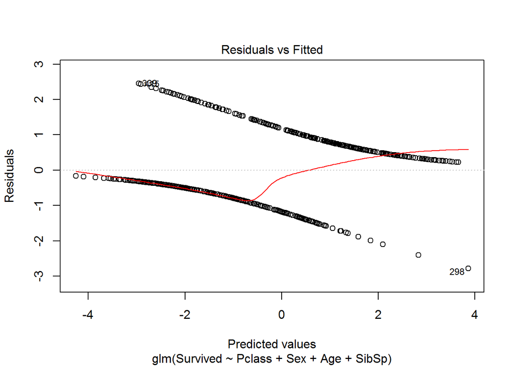

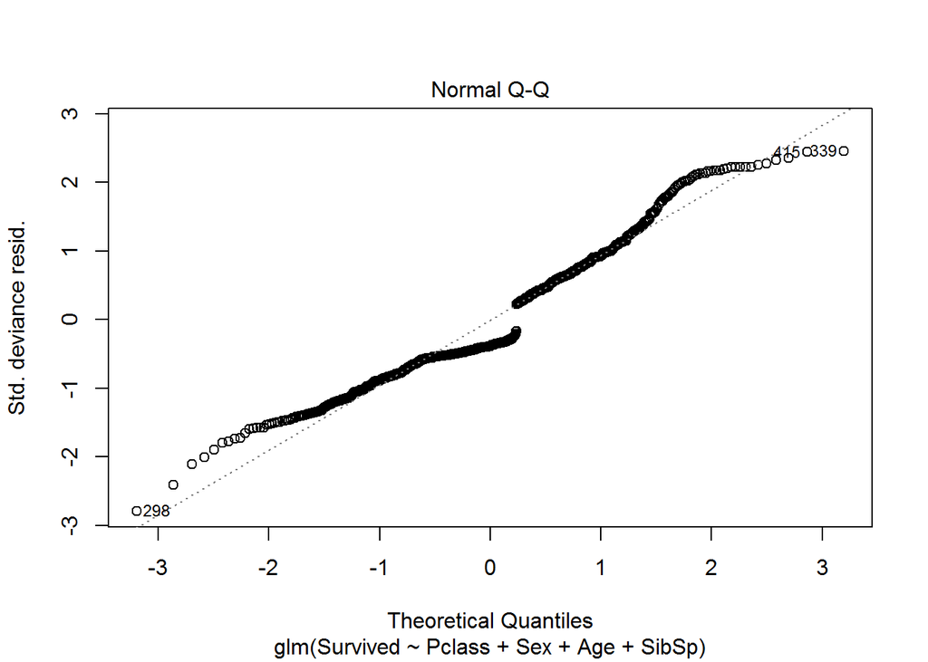

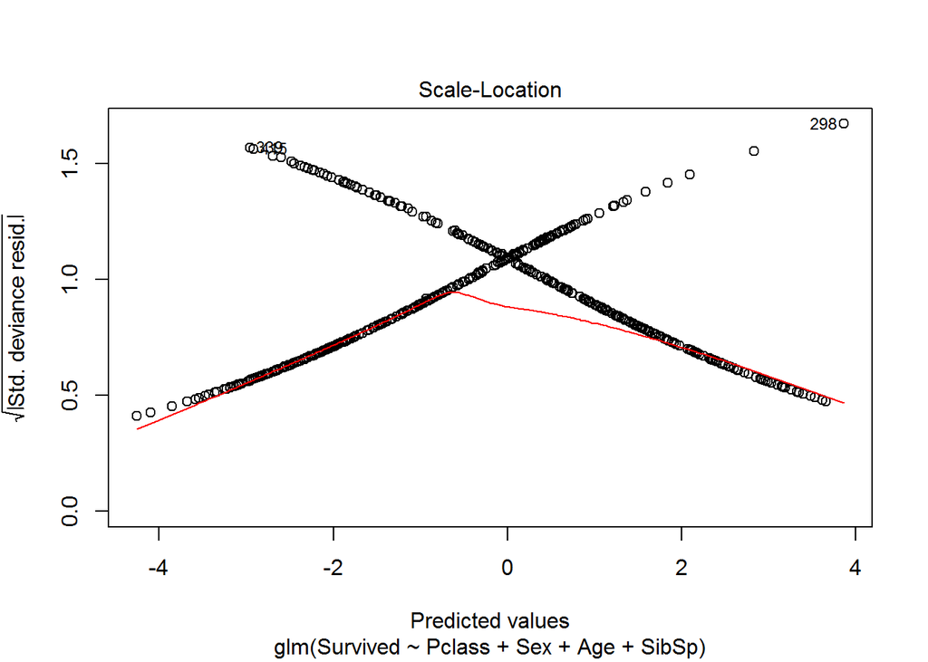

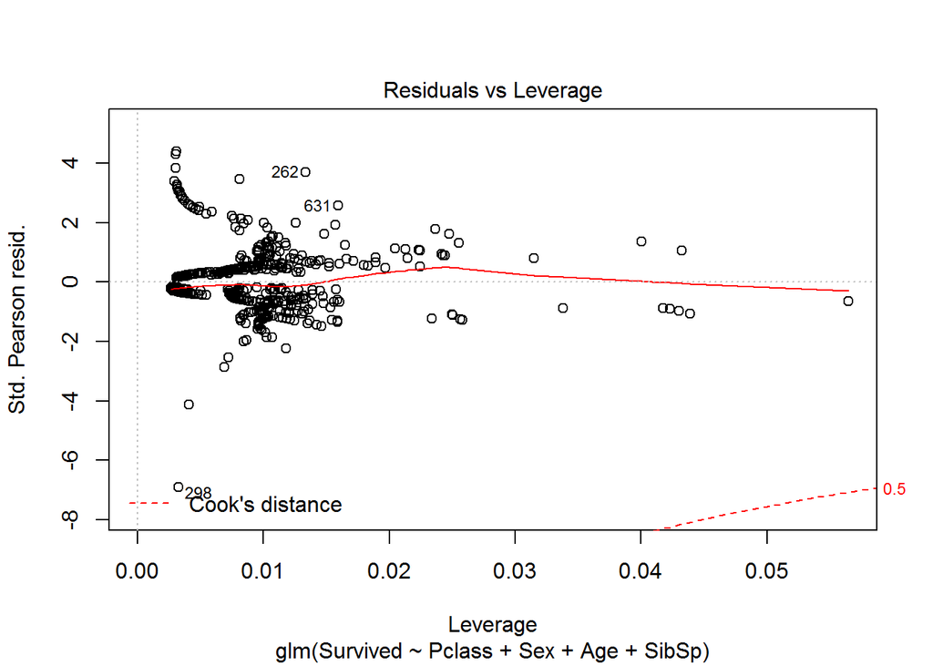

```r
plot(reg3)
```

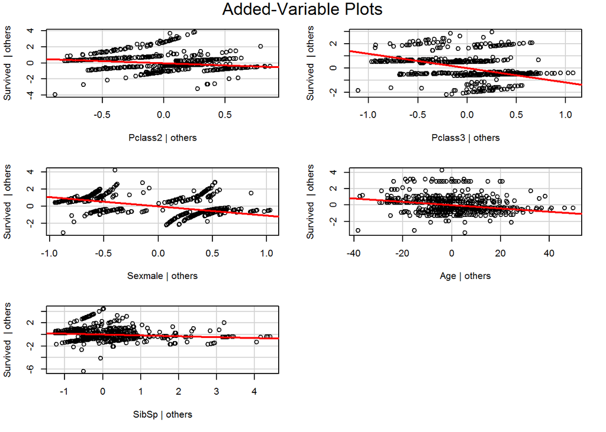

```r
avPlots(reg3)
```

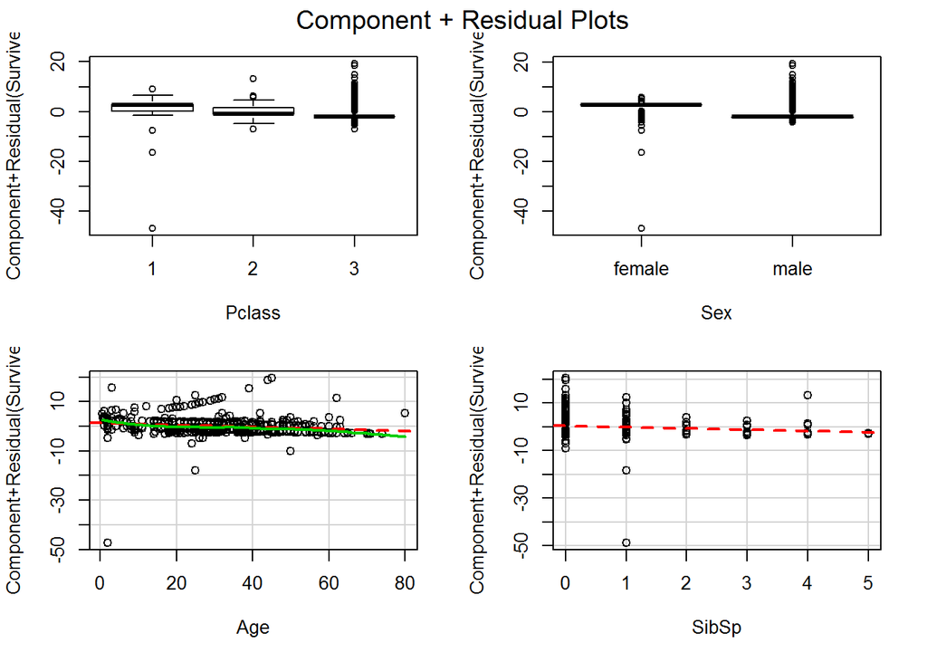

```r
crPlots(reg3)
```

- For the first set of plots, I do not see any glaring issues. The plots look reasonable for the most part. The main concern I could see is that there are some high leverage points in the data as indicated by the Residuals vs Leverage plot.
- The Added-Variable Plots all look reasonable strong as well. The only plot that shows potentially low significance is SibSp. This variable was the most insignificant according to the summary of the regression model, so it is not surprising to see its line so flat. Still, I see little reason to remove it from the model.
- Lastly, what little can be gleaned from the Componet + Residual Plots shows that none of the variables display a nonlinear pattern. Therefore, there is no reason to transform any of the data.
- I did not know how to show how the imputed data affected the results, but I would assume that it helped form the coefficient (and therefore the Odds-Ratio) for Age. Assuming the imputations were close to the actual data, they probably helped the model. Still, with how few observations had imputed values, it might not have made much of a difference.